# Analytic Report: MAGIC Bean Population (Harvard Dataverse)

LCF5900 - Open Science and Reproducible Data

Ricardo Antonio Ruiz Cardozo

2026-06-21

## 1. Introduction

This document reflects the complete workflow of open data analysis for the LCF5900 course. Here, we reproduce the phenotypic and genotypic analysis of the MAGIC common bean population (Phaseolus vulgaris L.) based on the study by Diaz et al. (2020). By extracting the original datasets directly from the Harvard Dataverse, we ensure full transparency and reproducibility (Open Science).

```r
rm(list=ls(all=TRUE))
gc()
```

```
##           used (Mb) gc trigger (Mb) max used (Mb)
## Ncells  625468 33.5    1436015 76.7   702071 37.5
## Vcells 1168287  9.0    8388608 64.0  1928020 14.8
```

```r
# Loading essential packages (added factoextra for PCA visualization)
required_packages <- c("tidyverse", "corrplot", "viridis", "gridExtra", "factoextra")
new_packages <- required_packages[!(required_packages %in% installed.packages()[,"Package"])]
if(length(new_packages)) install.packages(new_packages)

library(tidyverse)
library(corrplot)
library(viridis)
library(gridExtra)
library(factoextra)
```

### 2. Data Import

We load the raw field data, modeled genotypic effects (BLUPs), and the genetic map structure obtained from the Harvard Dataverse repository.

```r
url_base <- "https://raw.githubusercontent.com/raruizc/LCF5900-MAGIC-Bean-Genetics/main/data/"

url_raw_data <- paste0(url_base, "01.%20MAGIC_raw_data.csv")
url_model_data <- paste0(url_base, "03.%20MAGIC_model_data.csv")
url_map_data <- paste0(url_base, "06.%20MAGIC_genetic_map.csv")

dados_brutos <- read_csv(url_raw_data, na = c("NA", "", " "), show_col_types = FALSE)

dados_modelados <- read_csv(url_model_data, na = c("NA", "", " "), show_col_types = FALSE) %>%
  rename_with(trimws)

mapa_genetico <- read_csv(url_map_data, na = c("NA", "", " "), show_col_types = FALSE)
```

## 3. Descriptive Analysis: Agronomic Traits Across Years

We evaluate the impact of environmental variance across harvest years on crucial agronomic variables: Grain Yield (Yd) and 100-Seed Weight (100SdW).

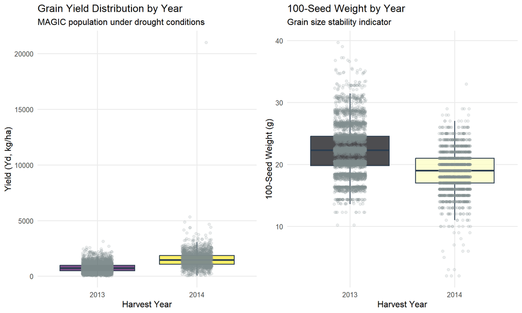

```r
# Plot 1: Yield (Yd) Boxplot
g1 <- dados_brutos %>%
  filter(!is.na(Yd), !is.na(Year)) %>%
  mutate(Year = as.factor(Year)) %>%
  ggplot(aes(x = Year, y = Yd, fill = Year)) +
  geom_boxplot(outlier.shape = NA, alpha = 0.7, color = "#2c3e50") +
  geom_jitter(width = 0.15, alpha = 0.15, color = "#7f8c8d") +
  scale_fill_viridis(discrete = TRUE, option = "viridis") +
  labs(
    title = "Grain Yield Distribution by Year",
    subtitle = "MAGIC population under drought conditions",
    x = "Harvest Year",
    y = "Yield (Yd, kg/ha)"
  ) +
  theme_minimal(base_size = 12) +
  theme(legend.position = "none", panel.grid.minor = element_blank())

# Plot 2: 100 Seed Weight Boxplot
g2 <- dados_brutos %>%
  filter(!is.na(`100SdW`), !is.na(Year)) %>%
  mutate(Year = as.factor(Year)) %>%
  ggplot(aes(x = Year, y = `100SdW`, fill = Year)) +
  geom_boxplot(outlier.shape = NA, alpha = 0.7, color = "#2c3e50") +
  geom_jitter(width = 0.15, alpha = 0.15, color = "#7f8c8d") +
  scale_fill_viridis(discrete = TRUE, option = "magma") +
  labs(
    title = "100-Seed Weight by Year",
    subtitle = "Grain size stability indicator",
    x = "Harvest Year",
    y = "100-Seed Weight (g)"
  ) +
  theme_minimal(base_size = 12) +
  theme(legend.position = "none", panel.grid.minor = element_blank())

# Rendering plots side by side
grid.arrange(g1, g2, ncol = 2)
```

## 4. Correlation Analysis: Phenotypic Traits (BLUPs)

To understand trait correlations (essential for crop breeding), we use the BLUP (Best Linear Unbiased Predictor) values estimated for 2014.

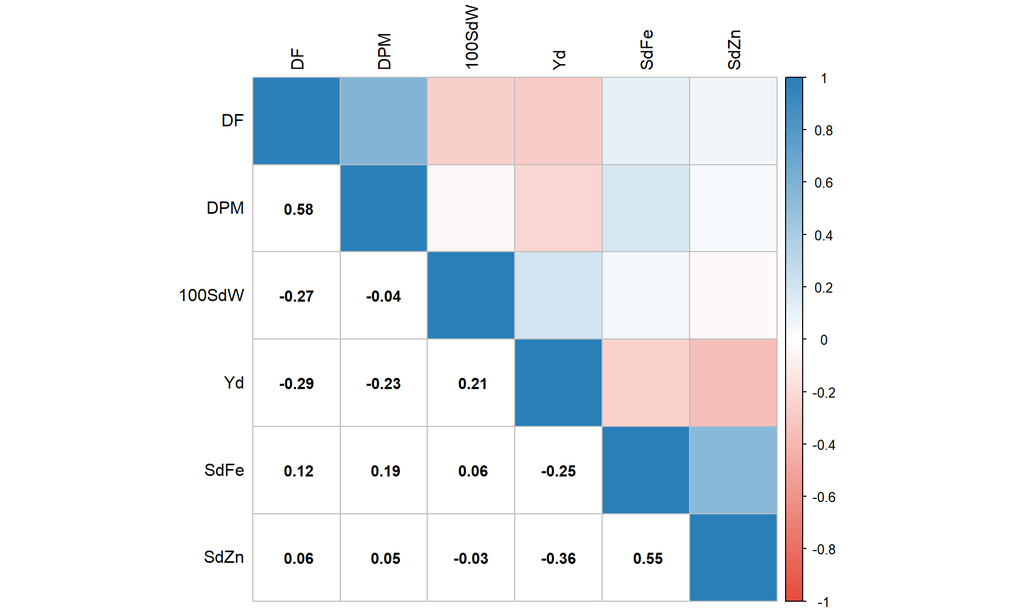

```r
# Filtering BLUP modeled data for the year 2014
# NOTE: 'PHI' was removed because it was not evaluated in 2014 (100% NA).
# Instead, we added Iron (SdFe) and Zinc (SdZn) concentrations.
df_cor_2014 <- dados_modelados %>%
  filter(Method == "BLUP", Year == 2014) %>%
  select(DF, DPM, `100SdW`, Yd, SdFe, SdZn) %>%
  mutate(across(everything(), as.numeric)) %>%
  drop_na()

# Calculating Pearson correlation matrix
matriz_cor_2014 <- cor(df_cor_2014, use = "complete.obs")

# Plotting the stylized correlation matrix
corrplot.mixed(
  matriz_cor_2014,
  lower = "number",
  upper = "color",
  tl.col = "black",
  tl.pos = "lt",
  diag = "n",
  bg = "transparent",
  lower.col = "black",
  number.cex = 0.9,
  upper.col = colorRampPalette(c("#e74c3c", "#ffffff", "#2980b9"))(200)
)
```

**Interpretation (2014 Data)**: The 2014 matrix reveals a crucial biological insight regarding biofortification: there is a notable correlation between Iron (SdFe) and Zinc (SdZn) accumulation in the seeds. This suggests that breeding strategies could simultaneously improve both micronutrients. However, we must monitor the relationship between these nutrients and overall yield (Yd) to avoid yield penalties when selecting for higher nutritional content.

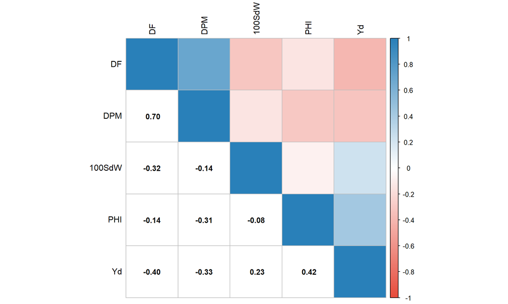

```r
### Year 2013
df_cor_2013 <- dados_modelados %>%
  filter(Method == "BLUP", Year == 2013) %>%
  select(DF, DPM, `100SdW`, PHI, Yd) %>%
  mutate(across(everything(), as.numeric)) %>%
  drop_na()

# Calculating Pearson correlation matrix
matriz_cor_2013 <- cor(df_cor_2013, use = "complete.obs")

# Plotting the stylized correlation matrix
corrplot.mixed(
  matriz_cor_2013,
  lower = "number",
  upper = "color",
  tl.col = "black",
  tl.pos = "lt",
  diag = "n",
  bg = "transparent",
  lower.col = "black",
  number.cex = 0.9,
  upper.col = colorRampPalette(c("#e74c3c", "#ffffff", "#2980b9"))(200)
)
```

## 5. Genetic Map Structure Analysis

Visualizing the physical distribution of Single Nucleotide Polymorphisms (SNPs) across the common bean genome.

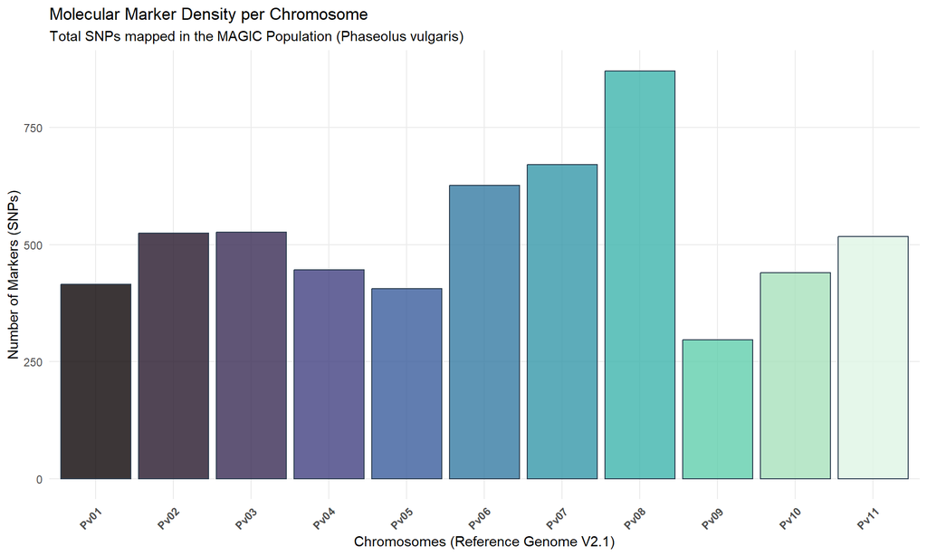

```r
mapa_genetico %>%
  filter(!is.na(Chromosome)) %>%
  ggplot(aes(x = Chromosome, fill = Chromosome)) +
  geom_bar(color = "#2c3e50", alpha = 0.8) +
  scale_fill_viridis(discrete = TRUE, option = "mako") +
  labs(
    title = "Molecular Marker Density per Chromosome",
    subtitle = "Total SNPs mapped in the MAGIC Population (Phaseolus vulgaris)",
    x = "Chromosomes (Reference Genome V2.1)",
    y = "Number of Markers (SNPs)"
  ) +
  theme_minimal() +
  theme(
    legend.position = "none",
    axis.text.x = element_text(angle = 45, hjust = 1, face = "bold"),
    panel.grid.minor = element_blank()
  )
```

**Interpretation**: The marker density plot highlights the successful, genome-wide coverage achieved by the Genotyping-by-Sequencing (GBS) methodology used in this study, providing a robust framework for identifying QTLs. Furthermore, the successful reconstruction of this entire analytical workflow—from raw phenotypic distributions and missing-data handling to complex trait correlations and genetic map visualization—demonstrates the fundamental power of Open Science. By utilizing publicly available datasets from the Harvard Dataverse, we verified the original findings and ensured the reproducibility of agro-genomic research.

## 6. Drought Escape Mechanism: Phenology vs. Yield

A critical strategy for crops under drought stress is “Drought Escape”, where plants that flower earlier manage to produce grains before the soil moisture is completely depleted. Here we assess this hypothesis by plotting Days to Flowering (DF) against estimated Grain Yield (Yd).

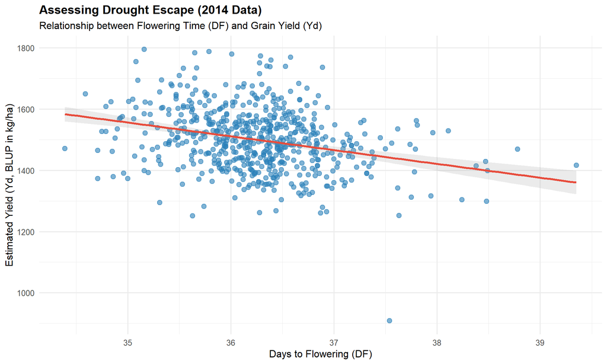

```r
df_escape <- dados_modelados %>%
  filter(Method == "BLUP", Year == 2014) %>%
  select(Line, DF, Yd) %>%
  drop_na()

ggplot(df_escape, aes(x = DF, y = Yd)) +
  geom_point(alpha = 0.6, color = "#2980b9", size = 2.5) +
  geom_smooth(method = "lm", color = "#e74c3c", se = TRUE, alpha = 0.2) +
  labs(
    title = "Assessing Drought Escape (2014 Data)",
    subtitle = "Relationship between Flowering Time (DF) and Grain Yield (Yd)",
    x = "Days to Flowering (DF)",
    y = "Estimated Yield (Yd, BLUP in kg/ha)"
  ) +
  theme_minimal(base_size = 12) +
  theme(plot.title = element_text(face = "bold"))
```

**Interpretation**: The scatter plot with the linear regression trendline confirms the drought escape mechanism. There is a negative association between flowering time and yield; bean lines that flowered earlier (lower DF) tended to maintain higher productivity (Yd) under the stress conditions of 2014, avoiding the peak of terminal drought.

## 7. Multivariate Analysis (PCA) of Genotypic Values

To understand the complex multivariate relationships among all traits simultaneously, we apply a Principal Component Analysis (PCA) on the BLUP values from the 2014 trial. This helps us visualize trade-offs and trait profiles across the entire MAGIC population.

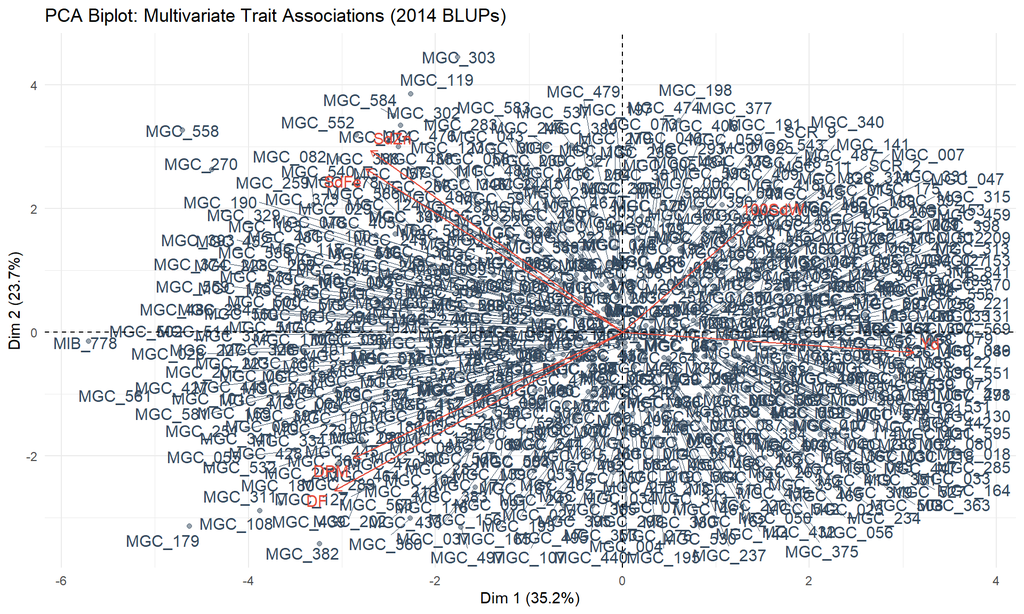

```r
# Preparing data for PCA (row names must be the Genotype lines)
df_pca <- dados_modelados %>%
  filter(Method == "BLUP", Year == 2014) %>%
  select(Line, DF, DPM, `100SdW`, Yd, SdFe, SdZn) %>%
  drop_na() %>%
  column_to_rownames(var = "Line")

# Computing PCA
pca_res <- prcomp(df_pca, scale. = TRUE)

# Visualizing PCA Biplot using factoextra
fviz_pca_biplot(pca_res,
                repel = TRUE, # Avoid text overlapping
                col.var = "#e74c3c", # Color for variables (arrows)
                col.ind = "#34495e", # Color for individuals (dots)
                alpha.ind = 0.5,
                title = "PCA Biplot: Multivariate Trait Associations (2014 BLUPs)",
                xlab = paste0("Dim 1 (", round(summary(pca_res)$importance[2,1]*100, 1), "%)"),
                ylab = paste0("Dim 2 (", round(summary(pca_res)$importance[2,2]*100, 1), "%)")) +
  theme_minimal()
```

## 8. Breeding Selection: Top Performing Genotypes

The ultimate goal of estimating BLUPs is genetic selection. This step isolates the top genotypes with the highest genetic merit for yield under severe drought conditions, representing the best candidates for cultivar release or future crosses.

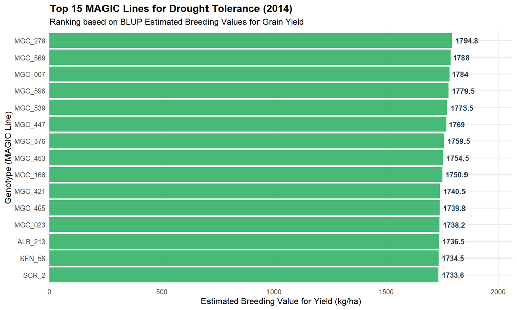

```r
# Selecting the top 15 genotypes based on Estimated Breeding Value for Yield
top_lines <- dados_modelados %>%
  filter(Method == "BLUP", Year == 2014) %>%
  select(Line, Yd) %>%
  drop_na() %>%
  arrange(desc(Yd)) %>%
  slice_head(n = 15)

ggplot(top_lines, aes(x = reorder(Line, Yd), y = Yd)) +
  geom_col(fill = "#27ae60", alpha = 0.85) +
  coord_flip() +
  geom_text(aes(label = round(Yd, 1)), hjust = -0.15, size = 3.5, fontface = "bold", color = "#2c3e50") +
  labs(
    title = "Top 15 MAGIC Lines for Drought Tolerance (2014)",
    subtitle = "Ranking based on BLUP Estimated Breeding Values for Grain Yield",
    x = "Genotype (MAGIC Line)",
    y = "Estimated Breeding Value for Yield (kg/ha)"
  ) +
  theme_minimal(base_size = 12) +
  scale_y_continuous(expand = expansion(mult = c(0, 0.15))) +
  theme(plot.title = element_text(face = "bold"))
```

*Conclusion*: The successful reconstruction of this entire analytical workflow—from raw phenotypic distributions to complex trait correlations, PCA multivariate clustering, and final elite genotype selection—demonstrates the fundamental power of Open Science. By utilizing publicly available datasets from the Harvard Dataverse, we verified the original findings and showcased a complete, reproducible pipeline for agro-genomic research.

## Data Source and References

To ensure full transparency, replicability, and proper attribution in accordance with Open Science principles, the original peer-reviewed article and its corresponding raw datasets are formally cited below:

Original Article: Diaz, S., Ariza-Suarez, D., Izquierdo, P. et al. (2020). Genetic mapping for agronomic traits in a MAGIC population of common bean (Phaseolus vulgaris L.) under drought conditions. BMC Genomics 21, 799. DOI: https://doi.org/10.1186/s12864-020-07213-6

Open Data Repository: Harvard Dataverse. Replication Data for: Genetic mapping for agronomic traits in a MAGIC population of common bean (Phaseolus vulgaris L.) under drought conditions. DOI: https://doi.org/10.7910/DVN/JR4X4C